# Detecting Potentially Fraudulent Medicare Providers

### A proof of concept for anomaly detection in healthcare payment

**Author:** Rhutika Patil **Topic:** Clinical Decision Making and Pattern Recognition in Health Care **Focus:** Anomaly detection for Payment (the "P" in Treatment, Payment, and Operations)

**What this notebook does, in one line:** it takes about 558,000 Medicare claims, rolls them up into one profile per provider, and tests three ways of spotting providers that look suspicious: simple statistical rules, an unsupervised model (Isolation Forest), and a supervised model (Logistic Regression).

**Structure (follows the data science lifecycle):**

1. Problem definition
2. Setup and data loading
3. Data quality checks
4. Data preparation: combining tables and building provider profiles with SQL
5. Exploratory data analysis (EDA)
6. Statistical analysis
7. Feature engineering and train/test split
8. Baseline: statistical rules
9. Unsupervised model: Isolation Forest
10. Supervised model: Logistic Regression
11. Evaluation and comparison
12. Explainability: why was a provider flagged?
13. Results summary
14. Conclusion, limitations, and next steps

## 1. Problem definition

**Business context.** Health plans pay millions of claims every day. A small share are improper: billed twice, billed for services never given, or billed at a higher level than the care provided. These errors and fraud cost the US healthcare system tens of billions of dollars a year. Payment integrity companies such as Cotiviti help payers catch these problems, ideally **before** the money goes out.

**Why Payment only.** Treatment, Payment, and Operations (TPO) all have anomaly detection use cases. This prototype focuses on Payment because (a) it is the core of Cotiviti's business and (b) claims data is the richest data available. The same approach extends to Treatment (for example unusual prescribing) and Operations (for example spikes in denials).

**The question.** Can we rank providers so that a small team of auditors reviews the most suspicious ones first?

**Data.** Kaggle, *Healthcare Provider Fraud Detection Analysis* (Gupta, 2019). Medicare style claims from 2009:

| File | What it holds | Level |
| --- | --- | --- |
| Beneficiary | Patient age, gender, state, chronic conditions | One row per patient |
| Inpatient | Hospital stay claims | One row per claim |
| Outpatient | Clinic and office claims | One row per claim |
| Labels | `PotentialFraud` = Yes / No | One row per provider |

**Unit of analysis: the provider.** Labels are given per provider, not per claim, so we summarize each provider's claims into one row of features.

**How we judge success.** Only about 1 in 10 providers is labeled as potential fraud, so accuracy is misleading (labeling everyone "not fraud" is already about 90% accurate). We use:

- **Recall:** of all fraud providers, how many did we catch?
- **Precision:** of the providers we flagged, how many were really fraud? (Auditor time is expensive.)
- **PR AUC:** one number summarizing the precision and recall tradeoff.
- **Precision at a review budget:** if auditors can only review the top 10% of providers, how many of those are real fraud?

## 2. Setup and data loading

All libraries are standard: pandas and numpy for data, sqlite3 (built into Python) for SQL, matplotlib and seaborn for charts, scipy for statistical tests, and scikit-learn for models.

The Kaggle file names include a long number (for example `Train-1542865627584.csv`), so we find each file with a pattern instead of typing the full name. We only use the **Train** files, because only they contain fraud labels.

```python
import glob
import sqlite3
import warnings

import numpy as np
import pandas as pd
import matplotlib.pyplot as plt
import seaborn as sns
from scipy import stats

from sklearn.model_selection import train_test_split
from sklearn.preprocessing import StandardScaler
from sklearn.ensemble import IsolationForest
from sklearn.linear_model import LogisticRegression
from sklearn.decomposition import PCA
from sklearn.metrics import (precision_score, recall_score, f1_score,
                             average_precision_score, roc_auc_score,
                             confusion_matrix, precision_recall_curve)

warnings.filterwarnings("ignore")
pd.set_option("display.max_columns", 50)
pd.set_option("display.float_format", "{:,.2f}".format)
sns.set_theme(style="whitegrid")

RANDOM_STATE = 42   # fixed seed so results are the same every run
DATA_DIR = "data"
```

```python
def find_file(pattern):
    """Return the one file in DATA_DIR that matches the pattern."""
    matches = glob.glob(f"{DATA_DIR}/{pattern}")
    if len(matches) != 1:
        raise FileNotFoundError(f"Expected 1 file for '{pattern}' in '{DATA_DIR}/', found {len(matches)}")
    return matches[0]

labels      = pd.read_csv(find_file("Train-*.csv"))
beneficiary = pd.read_csv(find_file("Train_Beneficiarydata-*.csv"))
inpatient   = pd.read_csv(find_file("Train_Inpatientdata-*.csv"))
outpatient  = pd.read_csv(find_file("Train_Outpatientdata-*.csv"))

for name, df in [("labels", labels), ("beneficiary", beneficiary),
                 ("inpatient", inpatient), ("outpatient", outpatient)]:
    print(f"{name:12s} {df.shape[0]:>8,} rows  {df.shape[1]:>3} columns")
```

```
labels          5,410 rows    2 columns
beneficiary   138,556 rows   25 columns
inpatient      40,474 rows   30 columns
outpatient    517,737 rows   27 columns
```

```python
outpatient.head(3)
```

|  | BeneID | ClaimID | ClaimStartDt | ClaimEndDt | Provider | InscClaimAmtReimbursed | AttendingPhysician | OperatingPhysician | OtherPhysician | ClmDiagnosisCode_1 | ClmDiagnosisCode_2 | ClmDiagnosisCode_3 | ClmDiagnosisCode_4 | ClmDiagnosisCode_5 | ClmDiagnosisCode_6 | ClmDiagnosisCode_7 | ClmDiagnosisCode_8 | ClmDiagnosisCode_9 | ClmDiagnosisCode_10 | ClmProcedureCode_1 | ClmProcedureCode_2 | ClmProcedureCode_3 | ClmProcedureCode_4 | ClmProcedureCode_5 | ClmProcedureCode_6 | DeductibleAmtPaid | ClmAdmitDiagnosisCode |
| --- | --- | --- | --- | --- | --- | --- | --- | --- | --- | --- | --- | --- | --- | --- | --- | --- | --- | --- | --- | --- | --- | --- | --- | --- | --- | --- | --- |
| 0 | BENE11002 | CLM624349 | 2009-10-11 | 2009-10-11 | PRV56011 | 30 | PHY326117 | NaN | NaN | 78943 | V5866 | V1272 | NaN | NaN | NaN | NaN | NaN | NaN | NaN | NaN | NaN | NaN | NaN | NaN | NaN | 0 | 56409 |
| 1 | BENE11003 | CLM189947 | 2009-02-12 | 2009-02-12 | PRV57610 | 80 | PHY362868 | NaN | NaN | 6115 | NaN | NaN | NaN | NaN | NaN | NaN | NaN | NaN | NaN | NaN | NaN | NaN | NaN | NaN | NaN | 0 | 79380 |
| 2 | BENE11003 | CLM438021 | 2009-06-27 | 2009-06-27 | PRV57595 | 10 | PHY328821 | NaN | NaN | 2723 | NaN | NaN | NaN | NaN | NaN | NaN | NaN | NaN | NaN | NaN | NaN | NaN | NaN | NaN | NaN | 0 | NaN |

## 3. Data quality checks

Before any analysis we check that the data is usable:

- Are key IDs missing?
- Are claim IDs unique?
- Do dates parse correctly and make sense (end date not before start date)?
- How balanced are the labels?

Missing values in columns like `OperatingPhysician` or `ClmProcedureCode_3` are **expected**: not every claim has a surgeon or a third procedure. Those blanks carry meaning, so we do not fill them in.

```python
# Missing values in the key columns we rely on
key_cols = ["BeneID", "ClaimID", "Provider", "ClaimStartDt", "ClaimEndDt", "InscClaimAmtReimbursed"]
print("Missing values in key columns")
print("  Inpatient :", inpatient[key_cols].isna().sum().sum())
print("  Outpatient:", outpatient[key_cols].isna().sum().sum())

# Claim IDs should be unique across both claim tables
all_ids = pd.concat([inpatient["ClaimID"], outpatient["ClaimID"]])
print("\nDuplicate ClaimIDs:", all_ids.duplicated().sum())

# Every provider in the claims should have a label
claim_providers = set(inpatient["Provider"]) | set(outpatient["Provider"])
print("Providers in claims without a label:", len(claim_providers - set(labels["Provider"])))

# Deductible has a few blanks in inpatient data; a blank means nothing was paid
print("Missing DeductibleAmtPaid (inpatient):", inpatient["DeductibleAmtPaid"].isna().sum())
```

```
Missing values in key columns
  Inpatient : 0
  Outpatient: 0
```

```
Duplicate ClaimIDs: 0
```

```
Providers in claims without a label: 0
Missing DeductibleAmtPaid (inpatient): 899
```

```python
# Convert date columns from text to real dates
for df in [inpatient, outpatient]:
    df["ClaimStartDt"] = pd.to_datetime(df["ClaimStartDt"])
    df["ClaimEndDt"] = pd.to_datetime(df["ClaimEndDt"])
beneficiary["DOB"] = pd.to_datetime(beneficiary["DOB"])
beneficiary["DOD"] = pd.to_datetime(beneficiary["DOD"])

bad_dates = sum((df["ClaimEndDt"] < df["ClaimStartDt"]).sum() for df in [inpatient, outpatient])
print("Claims ending before they start:", bad_dates)
print("Claim date range:", outpatient["ClaimStartDt"].min().date(), "to", outpatient["ClaimStartDt"].max().date())
print("Negative reimbursement amounts:",
      (inpatient["InscClaimAmtReimbursed"] < 0).sum() + (outpatient["InscClaimAmtReimbursed"] < 0).sum())
```

```
Claims ending before they start: 0
Claim date range: 2008-12-12 to 2009-12-31
Negative reimbursement amounts: 0
```

```python
# Label balance
fraud_counts = labels["PotentialFraud"].value_counts()
print(fraud_counts)
print(f"\nShare of providers labeled potential fraud: {fraud_counts['Yes'] / len(labels):.1%}")
```

```
PotentialFraud
No     4904
Yes     506
Name: count, dtype: int64

Share of providers labeled potential fraud: 9.4%
```

**Takeaway.** The data is clean: no missing IDs, no duplicate claims, sensible dates. The labels are **imbalanced** (roughly 9 non fraud providers for every fraud provider), which shapes every modeling choice later.

## 4. Data preparation: combining tables and building provider profiles

This happens in three steps:

1. **Stack** inpatient and outpatient claims into one claims table, with a flag saying which type each claim is.
2. **Add patient details** (age, chronic conditions) from the beneficiary table.
3. **Summarize with SQL:** load the claims into a small SQLite database in memory and use `GROUP BY Provider` to build one row per provider.

Why SQL here? In a real payer, claims live in a relational database and this rollup would be written in SQL. SQLite ships with Python, so no extra setup is needed.

*Analogy from genomics:* this is like turning millions of sequencing reads into a gene count matrix. Claims are the reads, providers are the genes, and the features are the counts.

```python
# Step 1: stack the two claim tables
inpatient["is_inpatient"] = 1
outpatient["is_inpatient"] = 0
claims = pd.concat([inpatient, outpatient], ignore_index=True)

# Simple claim level fields
claims["claim_days"] = (claims["ClaimEndDt"] - claims["ClaimStartDt"]).dt.days + 1
claims["DeductibleAmtPaid"] = claims["DeductibleAmtPaid"].fillna(0)

diag_cols = [c for c in claims.columns if c.startswith("ClmDiagnosisCode_")]
proc_cols = [c for c in claims.columns if c.startswith("ClmProcedureCode_")]
claims["n_diagnosis_codes"] = claims[diag_cols].notna().sum(axis=1)
claims["n_procedure_codes"] = claims[proc_cols].notna().sum(axis=1)

print("Combined claims:", f"{len(claims):,}")
```

```
Combined claims: 558,211
```

```python
# Step 2: add patient details
chronic_cols = [c for c in beneficiary.columns if c.startswith("ChronicCond_")]
bene = beneficiary[["BeneID", "DOB", "DOD"] + chronic_cols].copy()

# In this dataset 1 = has the condition, 2 = does not. Convert to 1 / 0 and count.
bene["n_chronic_conditions"] = (bene[chronic_cols] == 1).sum(axis=1)
bene["is_deceased"] = bene["DOD"].notna().astype(int)

claims = claims.merge(bene[["BeneID", "DOB", "n_chronic_conditions", "is_deceased"]],
                      on="BeneID", how="left")
claims["patient_age"] = (claims["ClaimStartDt"] - claims["DOB"]).dt.days / 365.25

claims[["ClaimID", "Provider", "is_inpatient", "InscClaimAmtReimbursed",
        "claim_days", "patient_age", "n_chronic_conditions"]].head()
```

|  | ClaimID | Provider | is_inpatient | InscClaimAmtReimbursed | claim_days | patient_age | n_chronic_conditions |
| --- | --- | --- | --- | --- | --- | --- | --- |
| 0 | CLM46614 | PRV55912 | 1 | 26000 | 7 | 66.28 | 7 |
| 1 | CLM66048 | PRV55907 | 1 | 5000 | 3 | 66.66 | 7 |
| 2 | CLM68358 | PRV56046 | 1 | 5000 | 4 | 66.71 | 7 |
| 3 | CLM38412 | PRV52405 | 1 | 5000 | 9 | 94.96 | 6 |
| 4 | CLM63689 | PRV56614 | 1 | 10000 | 18 | 71.37 | 5 |

```python
# Step 3: load into an in memory SQLite database
conn = sqlite3.connect(":memory:")

sql_cols = ["ClaimID", "BeneID", "Provider", "AttendingPhysician", "ClaimStartDt",
            "ClmDiagnosisCode_1", "InscClaimAmtReimbursed", "DeductibleAmtPaid",
            "is_inpatient", "claim_days", "n_diagnosis_codes", "n_procedure_codes",
            "patient_age", "n_chronic_conditions", "is_deceased"]
claims_sql = claims[sql_cols].copy()
claims_sql["ClaimStartDt"] = claims_sql["ClaimStartDt"].dt.strftime("%Y-%m-%d")
claims_sql.to_sql("claims", conn, index=False)
labels.to_sql("labels", conn, index=False)
print("Tables loaded:", pd.read_sql("SELECT name FROM sqlite_master WHERE type='table'", conn)["name"].tolist())
```

```
Tables loaded: ['claims', 'labels']
```

The query below builds the provider profile. Two parts are worth pointing out:

- **`dup_claims` (the subquery):** counts claims where the same patient, same start date, and same main diagnosis appear more than once for a provider. Duplicate billing is one of the most common improper payment patterns. (Spoiler: this dataset has very few of them, so the feature adds little here. In real payer data this check matters a lot, so it stays in as a template.)
- **The final join** attaches the fraud label to each provider.

```python
provider_query = """
WITH dup_claims AS (
    SELECT Provider, SUM(cnt) AS n_duplicate_like_claims
    FROM (
        SELECT Provider, BeneID, ClaimStartDt, ClmDiagnosisCode_1, COUNT(*) AS cnt
        FROM claims
        GROUP BY Provider, BeneID, ClaimStartDt, ClmDiagnosisCode_1
        HAVING COUNT(*) > 1
    )
    GROUP BY Provider
),
provider_stats AS (
    SELECT
        Provider,
        COUNT(*)                              AS n_claims,
        SUM(is_inpatient)                     AS n_inpatient_claims,
        COUNT(DISTINCT BeneID)                AS n_patients,
        COUNT(DISTINCT AttendingPhysician)    AS n_physicians,
        SUM(InscClaimAmtReimbursed)           AS total_reimbursed,
        AVG(InscClaimAmtReimbursed)           AS avg_reimbursed,
        MAX(InscClaimAmtReimbursed)           AS max_reimbursed,
        AVG(DeductibleAmtPaid)                AS avg_deductible,
        AVG(claim_days)                       AS avg_claim_days,
        AVG(n_diagnosis_codes)                AS avg_diagnosis_codes,
        AVG(n_procedure_codes)                AS avg_procedure_codes,
        AVG(patient_age)                      AS avg_patient_age,
        AVG(n_chronic_conditions)             AS avg_chronic_conditions,
        AVG(is_deceased)                      AS share_deceased_patients
    FROM claims
    GROUP BY Provider
)
SELECT
    p.*,
    COALESCE(d.n_duplicate_like_claims, 0)    AS n_duplicate_like_claims,
    CASE WHEN l.PotentialFraud = 'Yes' THEN 1 ELSE 0 END AS is_fraud
FROM provider_stats p
LEFT JOIN dup_claims d ON p.Provider = d.Provider
JOIN labels l          ON p.Provider = l.Provider
"""

provider_df = pd.read_sql(provider_query, conn)
conn.close()

print("Provider profiles:", provider_df.shape)
provider_df.head()
```

```
Provider profiles: (5410, 17)
```

|  | Provider | n_claims | n_inpatient_claims | n_patients | n_physicians | total_reimbursed | avg_reimbursed | max_reimbursed | avg_deductible | avg_claim_days | avg_diagnosis_codes | avg_procedure_codes | avg_patient_age | avg_chronic_conditions | share_deceased_patients | n_duplicate_like_claims | is_fraud |
| --- | --- | --- | --- | --- | --- | --- | --- | --- | --- | --- | --- | --- | --- | --- | --- | --- | --- |
| 0 | PRV51001 | 25 | 5 | 24 | 14 | 104640 | 4,185.60 | 42000 | 213.60 | 2.44 | 3.20 | 0.12 | 78.21 | 5.56 | 0.00 | 0 | 0 |
| 1 | PRV51003 | 132 | 62 | 117 | 44 | 605670 | 4,588.41 | 57000 | 502.17 | 4.67 | 5.25 | 0.36 | 69.54 | 4.55 | 0.01 | 0 | 1 |
| 2 | PRV51004 | 149 | 0 | 138 | 38 | 52170 | 350.13 | 3300 | 2.08 | 2.43 | 2.58 | 0.00 | 71.74 | 4.34 | 0.01 | 0 | 0 |
| 3 | PRV51005 | 1165 | 0 | 495 | 6 | 280910 | 241.12 | 4080 | 3.18 | 2.09 | 2.59 | 0.00 | 70.03 | 4.34 | 0.00 | 0 | 1 |
| 4 | PRV51007 | 72 | 3 | 58 | 10 | 33710 | 468.19 | 10000 | 45.33 | 1.96 | 2.99 | 0.01 | 68.79 | 4.17 | 0.01 | 0 | 0 |

## 5. Exploratory data analysis (EDA)

Goal: get a feel for the data before modeling. Key questions:

- How big are providers, and how skewed is that?
- Do fraud providers look different from the rest?
- Which features move together?

```python
provider_df.drop(columns=["Provider"]).describe().T
```

|  | count | mean | std | min | 25% | 50% | 75% | max |
| --- | --- | --- | --- | --- | --- | --- | --- | --- |
| n_claims | 5,410.00 | 103.18 | 272.46 | 1.00 | 10.00 | 31.00 | 87.00 | 8,240.00 |
| n_inpatient_claims | 5,410.00 | 7.48 | 23.70 | 0.00 | 0.00 | 0.00 | 5.00 | 516.00 |
| n_patients | 5,410.00 | 67.15 | 142.75 | 1.00 | 8.00 | 25.00 | 65.00 | 2,857.00 |
| n_physicians | 5,410.00 | 16.25 | 28.86 | 1.00 | 2.00 | 6.00 | 19.00 | 643.00 |
| total_reimbursed | 5,410.00 | 102,873.04 | 268,736.68 | 0.00 | 4,460.00 | 19,805.00 | 85,565.00 | 5,996,050.00 |
| avg_reimbursed | 5,410.00 | 1,740.68 | 3,484.47 | 0.00 | 232.39 | 356.09 | 1,490.15 | 57,000.00 |
| max_reimbursed | 5,410.00 | 13,014.91 | 18,995.32 | 0.00 | 1,700.00 | 3,300.00 | 17,000.00 | 125,000.00 |
| avg_deductible | 5,410.00 | 153.18 | 300.94 | 0.00 | 0.31 | 4.29 | 137.12 | 1,068.00 |
| avg_claim_days | 5,410.00 | 3.01 | 2.06 | 1.00 | 1.88 | 2.59 | 3.54 | 36.00 |
| avg_diagnosis_codes | 5,410.00 | 3.41 | 1.73 | 0.00 | 2.50 | 2.81 | 3.57 | 10.00 |
| avg_procedure_codes | 5,410.00 | 0.11 | 0.25 | 0.00 | 0.00 | 0.00 | 0.08 | 3.00 |
| avg_patient_age | 5,410.00 | 73.26 | 4.71 | 33.34 | 71.28 | 73.39 | 75.30 | 99.73 |
| avg_chronic_conditions | 5,410.00 | 4.54 | 0.89 | 0.00 | 4.15 | 4.51 | 4.93 | 10.00 |
| share_deceased_patients | 5,410.00 | 0.01 | 0.03 | 0.00 | 0.00 | 0.00 | 0.00 | 1.00 |
| n_duplicate_like_claims | 5,410.00 | 0.02 | 0.18 | 0.00 | 0.00 | 0.00 | 0.00 | 2.00 |
| is_fraud | 5,410.00 | 0.09 | 0.29 | 0.00 | 0.00 | 0.00 | 0.00 | 1.00 |

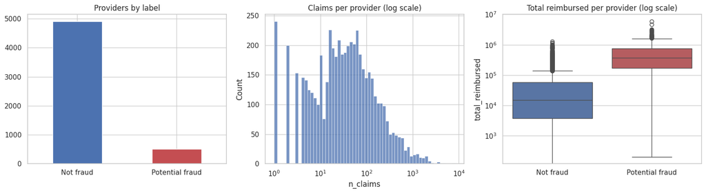

```python
fig, axes = plt.subplots(1, 3, figsize=(16, 4.5))

# Label balance
provider_df["is_fraud"].map({0: "Not fraud", 1: "Potential fraud"}).value_counts().plot(
    kind="bar", ax=axes[0], color=["#4C72B0", "#C44E52"])
axes[0].set_title("Providers by label")
axes[0].set_xlabel("")
axes[0].tick_params(axis="x", rotation=0)

# Claims per provider (log scale because of heavy skew)
sns.histplot(provider_df["n_claims"], bins=60, log_scale=True, ax=axes[1])
axes[1].set_title("Claims per provider (log scale)")

# Total reimbursed by label
sns.boxplot(data=provider_df, x="is_fraud", y="total_reimbursed", ax=axes[2],
            palette=["#4C72B0", "#C44E52"])
axes[2].set_yscale("log")
axes[2].set_xticklabels(["Not fraud", "Potential fraud"])
axes[2].set_xlabel("")
axes[2].set_title("Total reimbursed per provider (log scale)")

plt.tight_layout()
plt.show()
```

**What we see:**

- Provider size is **very skewed**: most providers have a handful of claims, a few have thousands. We will use log transforms before modeling.
- Providers labeled as potential fraud tend to bill **much more in total** than other providers. Size alone is a strong signal, but it is also a trap: big honest hospitals bill a lot too.

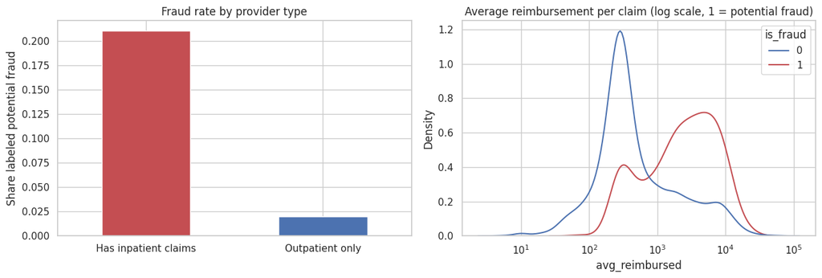

```
has_inpatient
Has inpatient claims    21.0%
Outpatient only          2.0%
Name: is_fraud, dtype: str
```

```python
# Share of inpatient claims, fraud vs not
provider_df["inpatient_share"] = provider_df["n_inpatient_claims"] / provider_df["n_claims"]

fig, axes = plt.subplots(1, 2, figsize=(13, 4.5))
fraud_rate_by_type = provider_df.assign(
    has_inpatient=np.where(provider_df["n_inpatient_claims"] > 0, "Has inpatient claims", "Outpatient only")
).groupby("has_inpatient")["is_fraud"].mean()
fraud_rate_by_type.plot(kind="bar", ax=axes[0], color=["#C44E52", "#4C72B0"])
axes[0].set_title("Fraud rate by provider type")
axes[0].set_ylabel("Share labeled potential fraud")
axes[0].set_xlabel("")
axes[0].tick_params(axis="x", rotation=0)

# a few providers have $0 average (all claims unpaid); log scale cannot show zero, so leave them out of this chart
sns.kdeplot(data=provider_df[provider_df["avg_reimbursed"] > 0], x="avg_reimbursed", hue="is_fraud", log_scale=True,
            common_norm=False, ax=axes[1], palette=["#4C72B0", "#C44E52"])
axes[1].set_title("Average reimbursement per claim (log scale, 1 = potential fraud)")
plt.tight_layout()
plt.show()

print(fraud_rate_by_type.apply(lambda x: f"{x:.1%}"))
```

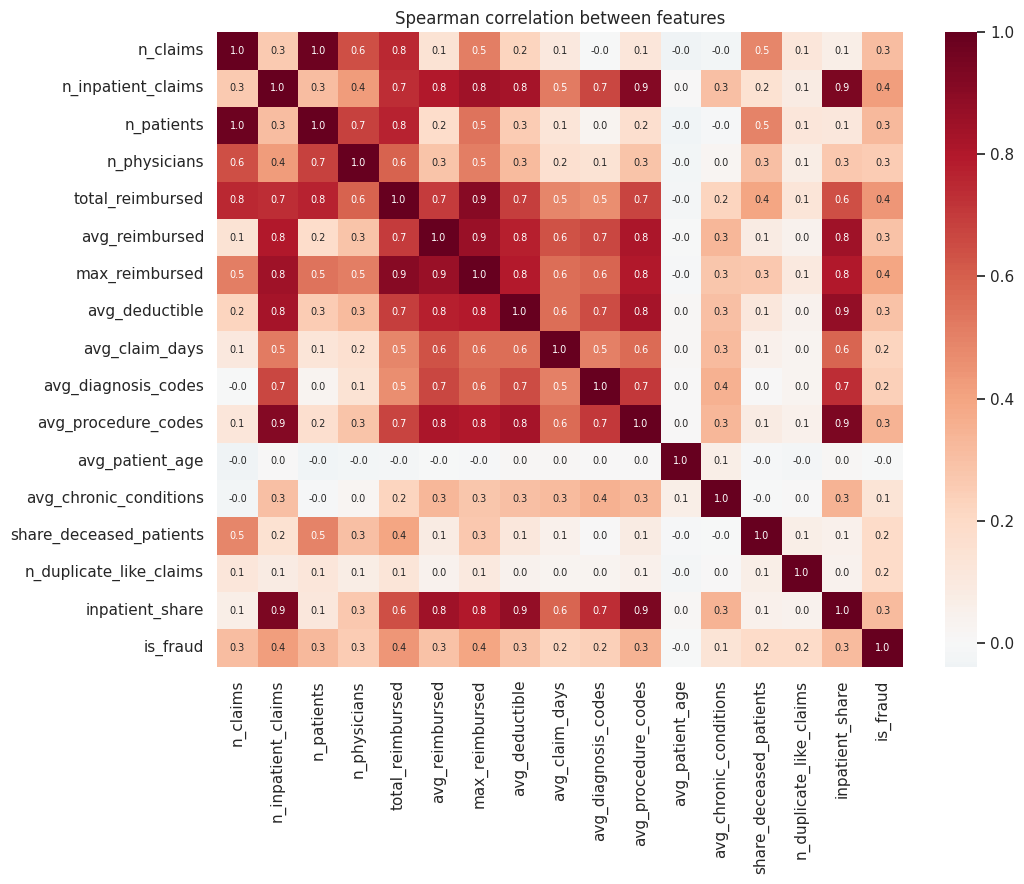

```python
feature_cols = ["n_claims", "n_inpatient_claims", "n_patients", "n_physicians",
                "total_reimbursed", "avg_reimbursed", "max_reimbursed", "avg_deductible",
                "avg_claim_days", "avg_diagnosis_codes", "avg_procedure_codes",
                "avg_patient_age", "avg_chronic_conditions", "share_deceased_patients",
                "n_duplicate_like_claims", "inpatient_share"]

plt.figure(figsize=(11, 9))
sns.heatmap(provider_df[feature_cols + ["is_fraud"]].corr(method="spearman"),
            cmap="RdBu_r", center=0, annot=True, fmt=".1f", annot_kws={"size": 7})
plt.title("Spearman correlation between features")
plt.tight_layout()
plt.show()
```

**What we see:**

- Providers with **any inpatient claims** have a far higher fraud rate than outpatient only providers.
- **Volume features move together:** number of claims, patients, physicians, and total reimbursed are strongly correlated. They mostly measure "how big is this provider." We keep them, but this redundancy matters for Logistic Regression (Section 10), where correlated inputs make individual coefficients less reliable.
- Spearman correlation (rank based) is used instead of Pearson because the data is heavily skewed.

## 6. Statistical analysis

Two questions:

**6a. Are fraud and non fraud providers really different?** We use the **Mann Whitney U test**, which compares two groups without assuming a normal distribution. That suits this skewed data. (It is the same kind of non parametric test used for comparing expression between two conditions.) With about 5,400 providers, even tiny differences can be "significant," so we also look at the **ratio of medians** to judge how big the difference is.

**6b. Do simple outlier rules find fraud?** We compute a **z score** (how many standard deviations above average a provider is) on the log of key features and see how often extreme providers are labeled fraud.

```python
fraud = provider_df[provider_df["is_fraud"] == 1]
not_fraud = provider_df[provider_df["is_fraud"] == 0]

rows = []
for col in feature_cols:
    stat, p_value = stats.mannwhitneyu(fraud[col], not_fraud[col], alternative="two-sided")
    med_f, med_nf = fraud[col].median(), not_fraud[col].median()
    rows.append({
        "feature": col,
        "median_fraud": med_f,
        "median_not_fraud": med_nf,
        "ratio": med_f / med_nf if med_nf != 0 else np.nan,
        "p_value": p_value,
    })

stat_table = pd.DataFrame(rows).sort_values("p_value")
stat_table["significant (p < 0.01)"] = stat_table["p_value"] < 0.01
stat_table["p_value"] = stat_table["p_value"].map("{:.1e}".format)   # scientific notation, easier to read
stat_table
```

|  | feature | median_fraud | median_not_fraud | ratio | p_value | significant (p < 0.01) |
| --- | --- | --- | --- | --- | --- | --- |
| 4 | total_reimbursed | 373,450.00 | 15,055.00 | 24.81 | 4.2e-231 | True |
| 1 | n_inpatient_claims | 24.00 | 0.00 | NaN | 6.3e-213 | True |
| 6 | max_reimbursed | 46,000.00 | 3,300.00 | 13.94 | 2.2e-188 | True |
| 10 | avg_procedure_codes | 0.17 | 0.00 | NaN | 2.0e-142 | True |
| 2 | n_patients | 117.00 | 22.00 | 5.32 | 1.2e-124 | True |
| 15 | inpatient_share | 0.22 | 0.00 | NaN | 3.1e-121 | True |
| 0 | n_claims | 155.50 | 27.00 | 5.76 | 6.4e-117 | True |
| 7 | avg_deductible | 228.75 | 3.58 | 63.95 | 1.5e-102 | True |
| 5 | avg_reimbursed | 2,576.48 | 332.19 | 7.76 | 7.0e-102 | True |
| 3 | n_physicians | 23.00 | 5.00 | 4.60 | 1.8e-79 | True |
| 9 | avg_diagnosis_codes | 3.78 | 2.76 | 1.37 | 1.4e-68 | True |
| 8 | avg_claim_days | 3.48 | 2.51 | 1.38 | 1.8e-61 | True |
| 13 | share_deceased_patients | 0.00 | 0.00 | NaN | 1.2e-45 | True |
| 14 | n_duplicate_like_claims | 0.00 | 0.00 | NaN | 9.8e-44 | True |
| 12 | avg_chronic_conditions | 4.72 | 4.50 | 1.05 | 5.6e-24 | True |
| 11 | avg_patient_age | 73.44 | 73.37 | 1.00 | 7.2e-01 | False |

**Reading the table:** a ratio shows as blank (NaN) when the non fraud median is zero, for example most providers have no inpatient claims at all. A ratio above 1 means the typical fraud provider has a higher value than the typical non fraud provider. Volume and money features show the biggest gaps. Patient features (age, chronic conditions) differ much less, which makes sense: fraud is about **how providers bill**, not who their patients are.

```python
# z scores on log scale for three key volume and money features
zscore_features = ["total_reimbursed", "n_claims", "n_patients"]
for col in zscore_features:
    log_values = np.log1p(provider_df[col])
    provider_df[f"z_{col}"] = (log_values - log_values.mean()) / log_values.std()

overall_rate = provider_df["is_fraud"].mean()
print(f"Fraud rate across all providers: {overall_rate:.1%}\n")
for col in zscore_features:
    extreme = provider_df[provider_df[f"z_{col}"] > 2]
    print(f"Providers with z_{col} > 2: {len(extreme):4d}   fraud rate among them: {extreme['is_fraud'].mean():.1%}")
```

```
Fraud rate across all providers: 9.4%

Providers with z_total_reimbursed > 2:   35   fraud rate among them: 100.0%
Providers with z_n_claims > 2:  138   fraud rate among them: 58.7%
Providers with z_n_patients > 2:  138   fraud rate among them: 60.9%
```

**Takeaway.** Providers far above average on volume are several times more likely to be labeled fraud than the typical provider. That is the idea behind rule based payment edits, and it gives us a **baseline** to beat in Section 8.

## 7. Feature engineering and train/test split

Changes before modeling:

- **Log transform** skewed count and money features with `log1p` (log of 1 + x, safe for zeros). This stops a few huge providers from dominating.
- **Ratios** that describe billing behavior regardless of size:
  - `claims_per_patient`: how often each patient is billed
  - `reimbursed_per_patient`: money billed per patient
  - `duplicate_share`: share of claims that look like duplicates
- **Train/test split:** 80% to train, 20% to test, **stratified** so both sets keep the same fraud rate. Every method is judged on the same test set.
- **Scaling:** `StandardScaler` puts features on the same scale. It is fit on the training set only, so no information leaks from the test set.

```python
model_df = provider_df.copy()

model_df["claims_per_patient"] = model_df["n_claims"] / model_df["n_patients"]
model_df["reimbursed_per_patient"] = model_df["total_reimbursed"] / model_df["n_patients"]
model_df["duplicate_share"] = model_df["n_duplicate_like_claims"] / model_df["n_claims"]

log_cols = ["n_claims", "n_inpatient_claims", "n_patients", "n_physicians",
            "total_reimbursed", "avg_reimbursed", "max_reimbursed", "avg_deductible",
            "n_duplicate_like_claims", "reimbursed_per_patient"]
for col in log_cols:
    model_df[f"log_{col}"] = np.log1p(model_df[col])

model_features = [f"log_{c}" for c in log_cols] + [
    "avg_claim_days", "avg_diagnosis_codes", "avg_procedure_codes",
    "avg_patient_age", "avg_chronic_conditions", "share_deceased_patients",
    "inpatient_share", "claims_per_patient", "duplicate_share"]

print("Number of model features:", len(model_features))
```

```
Number of model features: 19
```

```python
X = model_df[model_features]
y = model_df["is_fraud"]

X_train, X_test, y_train, y_test = train_test_split(
    X, y, test_size=0.2, stratify=y, random_state=RANDOM_STATE)

scaler = StandardScaler()
X_train_scaled = scaler.fit_transform(X_train)   # learn mean and std from training data only
X_test_scaled = scaler.transform(X_test)          # apply the same scaling to test data

print(f"Train: {len(X_train):,} providers  fraud rate {y_train.mean():.1%}")
print(f"Test : {len(X_test):,} providers  fraud rate {y_test.mean():.1%}")
```

```
Train: 4,328 providers  fraud rate 9.4%
Test : 1,082 providers  fraud rate 9.3%
```

## 8. Baseline: statistical rules

The simplest approach, and how many payment integrity programs start: **flag a provider if any key feature is extreme.**

Rule: flag if the z score of log total reimbursed, log claim count, or log patient count is above a threshold. The mean and standard deviation come from the **training set**, then the rule is applied to the test set.

We pick the threshold so the rule flags about **10% of providers**, which matches the review budget used for the models. That keeps the comparison fair.

```python
REVIEW_BUDGET = 0.10   # auditors can review the top 10% of providers

def rule_score(X_part):
    """Highest z score across three key features, using training set mean and std."""
    cols = ["log_total_reimbursed", "log_n_claims", "log_n_patients"]
    z = (X_part[cols] - X_train[cols].mean()) / X_train[cols].std()
    return z.max(axis=1).values

train_rule_scores = rule_score(X_train)
rule_threshold = np.quantile(train_rule_scores, 1 - REVIEW_BUDGET)
print(f"Rule: flag if max z score > {rule_threshold:.2f}")

rule_scores_test = rule_score(X_test)
rule_pred = (rule_scores_test > rule_threshold).astype(int)
print(f"Flagged in test set: {rule_pred.sum()} of {len(rule_pred)}")
```

```
Rule: flag if max z score > 1.51
Flagged in test set: 125 of 1082
```

## 9. Unsupervised model: Isolation Forest

**Why unsupervised?** In the real world, confirmed fraud labels are rare, slow to arrive, and only cover patterns auditors already know. An unsupervised model needs **no labels**. It learns what "normal" looks like and flags what does not fit, so it can surface **new** schemes.

**How Isolation Forest works, simply:** it builds many random decision trees that keep splitting the data. Unusual providers are easy to separate, so they get isolated in only a few splits. The fewer splits needed, the more anomalous the provider. (Similar in spirit to filtering outlier cells in single cell QC.)

**Key setting:** `contamination = 0.10`, meaning "treat the most unusual 10% as anomalies." This matches the review budget. **Labels are not used to train it.** We only use them afterward to check how well it did.

```python
iso_forest = IsolationForest(n_estimators=300, contamination=REVIEW_BUDGET,
                             random_state=RANDOM_STATE)
iso_forest.fit(X_train_scaled)   # note: no y_train here

# score_samples is higher for normal points, so flip the sign: higher = more anomalous
iso_scores_test = -iso_forest.score_samples(X_test_scaled)
iso_pred = (iso_forest.predict(X_test_scaled) == -1).astype(int)   # -1 means anomaly

print(f"Flagged in test set: {iso_pred.sum()} of {len(iso_pred)}")
```

```
Flagged in test set: 120 of 1082
```

**Visual check with PCA.** PCA squeezes all features into 2 dimensions so we can plot providers. We color by the model's flag and mark the true fraud labels. This is only for looking; the model itself uses all features.

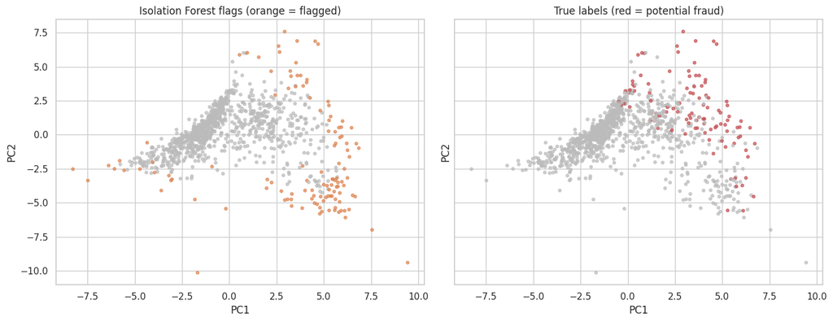

```
Variance explained by 2 components: 58%
```

```python
pca = PCA(n_components=2, random_state=RANDOM_STATE)
test_2d = pca.fit_transform(X_test_scaled)

fig, axes = plt.subplots(1, 2, figsize=(14, 5.5), sharex=True, sharey=True)
axes[0].scatter(test_2d[:, 0], test_2d[:, 1], c=np.where(iso_pred == 1, "#DD8452", "#BBBBBB"), s=12, alpha=0.7)
axes[0].set_title("Isolation Forest flags (orange = flagged)")
axes[1].scatter(test_2d[:, 0], test_2d[:, 1], c=np.where(y_test == 1, "#C44E52", "#BBBBBB"), s=12, alpha=0.7)
axes[1].set_title("True labels (red = potential fraud)")
for ax in axes:
    ax.set_xlabel("PC1")
    ax.set_ylabel("PC2")
plt.tight_layout()
plt.show()

print(f"Variance explained by 2 components: {pca.explained_variance_ratio_.sum():.0%}")
```

**What we see:** flagged providers sit toward the edges of the cloud. Many true fraud providers sit in that same region, but not all of them, and some flagged providers are not labeled fraud. That is expected: **unusual is not the same as fraudulent.**

## 10. Supervised model: Logistic Regression

**Why supervised?** Once auditors confirm cases, those labels can train a model to recognize **known** fraud patterns. This is usually more precise than unsupervised methods, but only for patterns that appear in past labels.

**Why Logistic Regression?**

- **Explainable:** each feature gets a weight. In payment decisions, payers must be able to justify why a claim or provider was flagged.
- **Simple and fast**, and a common first model before trying anything more complex.

**Handling imbalance:** `class_weight="balanced"` tells the model that missing a fraud provider matters more, because fraud cases are rare.

```python
log_reg = LogisticRegression(class_weight="balanced", max_iter=2000, random_state=RANDOM_STATE)
log_reg.fit(X_train_scaled, y_train)

lr_proba_test = log_reg.predict_proba(X_test_scaled)[:, 1]   # probability of fraud
lr_pred_default = (lr_proba_test >= 0.5).astype(int)

# For a fair comparison, also flag the top 10% most likely providers (same review budget)
lr_threshold = np.quantile(log_reg.predict_proba(X_train_scaled)[:, 1], 1 - REVIEW_BUDGET)
lr_pred = (lr_proba_test >= lr_threshold).astype(int)

print(f"Flagged at 0.5 cutoff        : {lr_pred_default.sum()} of {len(lr_pred_default)}")
print(f"Flagged at 10% review budget : {lr_pred.sum()} of {len(lr_pred)}")
```

```
Flagged at 0.5 cutoff        : 255 of 1082
Flagged at 10% review budget : 113 of 1082
```

## 11. Evaluation and comparison

All three methods are scored on the **same test set** that none of them trained on. Two views:

1. **At the 10% review budget:** precision, recall, F1.
2. **Ranking quality (PR AUC, ROC AUC):** how well each method's score ranks fraud providers above others, across every possible cutoff.

A random guess would have a PR AUC equal to the fraud rate (about 0.09), so that is the floor.

```python
def evaluate(name, y_true, y_pred, scores):
    """Collect the main metrics for one method."""
    return {
        "method": name,
        "flagged": int(y_pred.sum()),
        "precision": precision_score(y_true, y_pred, zero_division=0),
        "recall": recall_score(y_true, y_pred),
        "f1": f1_score(y_true, y_pred),
        "pr_auc": average_precision_score(y_true, scores),
        "roc_auc": roc_auc_score(y_true, scores),
    }

results = pd.DataFrame([
    evaluate("Rules (z score)", y_test, rule_pred, rule_scores_test),
    evaluate("Isolation Forest (no labels)", y_test, iso_pred, iso_scores_test),
    evaluate("Logistic Regression (labels)", y_test, lr_pred, lr_proba_test),
]).set_index("method")

print(f"Test set: {len(y_test)} providers, {int(y_test.sum())} labeled potential fraud "
      f"({y_test.mean():.1%} random baseline for PR AUC)\n")
results
```

```
Test set: 1082 providers, 101 labeled potential fraud (9.3% random baseline for PR AUC)
```

| method | flagged | precision | recall | f1 | pr_auc | roc_auc |
| --- | --- | --- | --- | --- | --- | --- |
| Rules (z score) | 125 | 0.46 | 0.57 | 0.51 | 0.58 | 0.92 |
| Isolation Forest (no labels) | 120 | 0.36 | 0.43 | 0.39 | 0.30 | 0.84 |
| Logistic Regression (labels) | 113 | 0.64 | 0.71 | 0.67 | 0.74 | 0.96 |

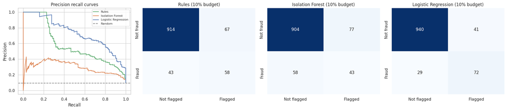

```python
fig, axes = plt.subplots(1, 4, figsize=(20, 4.5))

# Precision recall curves
for name, scores, color in [("Rules", rule_scores_test, "#55A868"),
                            ("Isolation Forest", iso_scores_test, "#DD8452"),
                            ("Logistic Regression", lr_proba_test, "#4C72B0")]:
    prec, rec, _ = precision_recall_curve(y_test, scores)
    axes[0].plot(rec, prec, label=name, color=color)
axes[0].axhline(y_test.mean(), ls="--", color="grey", label="Random")
axes[0].set_xlabel("Recall")
axes[0].set_ylabel("Precision")
axes[0].set_title("Precision recall curves")
axes[0].legend(fontsize=8)

# Confusion matrices at the 10% budget
for ax, (name, pred) in zip(axes[1:], [("Rules", rule_pred),
                                       ("Isolation Forest", iso_pred),
                                       ("Logistic Regression", lr_pred)]):
    cm = confusion_matrix(y_test, pred)
    sns.heatmap(cm, annot=True, fmt="d", cbar=False, cmap="Blues", ax=ax,
                xticklabels=["Not flagged", "Flagged"], yticklabels=["Not fraud", "Fraud"])
    ax.set_title(f"{name} (10% budget)")

plt.tight_layout()
plt.show()
```

**How to read this:**

- All three methods beat random by a wide margin.
- **Logistic Regression** does best, because it learns directly from labeled examples.
- **Rules** are a surprisingly strong baseline, because volume is such a strong signal in this data.
- **Isolation Forest** finds real signal **without any labels**, which matters where labels do not exist yet. It trails because it flags anything unusual, including large honest providers.

**Recall vs budget tradeoff:** with a 10% budget, we cannot catch every fraud provider, because there are about as many fraud providers as review slots and no method is perfect. The chart below shows how much fraud each method catches as the budget grows.

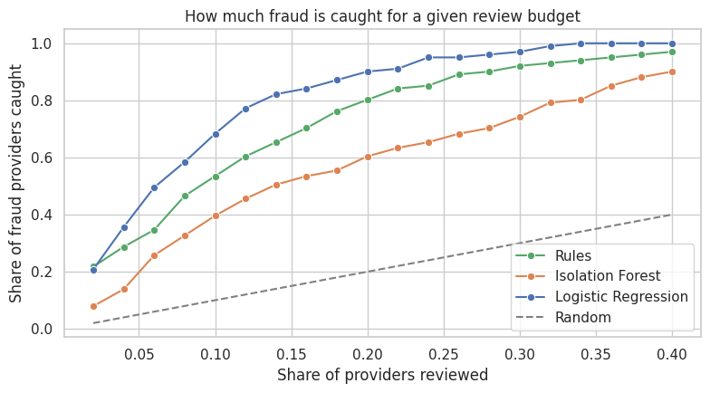

```python
budgets = np.arange(0.02, 0.41, 0.02)
curve_rows = []
for name, scores in [("Rules", rule_scores_test), ("Isolation Forest", iso_scores_test),
                     ("Logistic Regression", lr_proba_test)]:
    order = np.argsort(-scores)                      # most suspicious first
    sorted_labels = y_test.values[order]
    for b in budgets:
        k = int(round(b * len(scores)))
        curve_rows.append({"method": name, "budget": b,
                           "share_of_fraud_caught": sorted_labels[:k].sum() / y_test.sum()})
budget_curve = pd.DataFrame(curve_rows)

plt.figure(figsize=(8, 4.5))
sns.lineplot(data=budget_curve, x="budget", y="share_of_fraud_caught", hue="method", marker="o",
             palette={"Rules": "#55A868", "Isolation Forest": "#DD8452", "Logistic Regression": "#4C72B0"})
plt.plot(budgets, budgets, ls="--", color="grey", label="Random")
plt.xlabel("Share of providers reviewed")
plt.ylabel("Share of fraud providers caught")
plt.title("How much fraud is caught for a given review budget")
plt.legend()
plt.tight_layout()
plt.show()
```

## 12. Explainability: why was a provider flagged?

An auditor will not act on a score alone. They need a **reason**. With Logistic Regression we can explain each flag:

1. **Global view:** which features push the fraud probability up or down overall (the model's coefficients).
2. **Per provider view:** for a flagged provider, which features contributed most to its score (coefficient × that provider's scaled value). We turn the top two into a plain English reason.

Note: because volume features are correlated (Section 5), individual coefficients can split credit between them in odd ways, so we read them as **directions**, not exact effects.

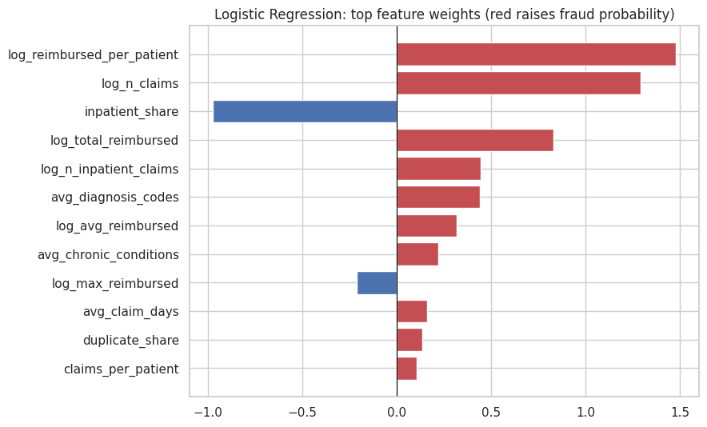

```python
coef_df = pd.DataFrame({"feature": model_features, "coefficient": log_reg.coef_[0]})
coef_df = coef_df.reindex(coef_df["coefficient"].abs().sort_values(ascending=False).index)

top_coef = coef_df.head(12).iloc[::-1]
plt.figure(figsize=(9, 5.5))
plt.barh(top_coef["feature"], top_coef["coefficient"],
         color=np.where(top_coef["coefficient"] > 0, "#C44E52", "#4C72B0"))
plt.axvline(0, color="black", lw=0.8)
plt.title("Logistic Regression: top feature weights (red raises fraud probability)")
plt.tight_layout()
plt.show()
```

```python
plain_english = {
    "log_n_claims": "high claim volume",
    "log_n_inpatient_claims": "many inpatient (hospital) claims",
    "log_n_patients": "many unique patients",
    "log_n_physicians": "many attending physicians",
    "log_total_reimbursed": "high total reimbursement",
    "log_avg_reimbursed": "high average amount per claim",
    "log_max_reimbursed": "very large single claim",
    "log_avg_deductible": "high average deductible",
    "log_n_duplicate_like_claims": "many duplicate looking claims",
    "log_reimbursed_per_patient": "high reimbursement per patient",
    "avg_claim_days": "long average claim duration",
    "avg_diagnosis_codes": "many diagnosis codes per claim",
    "avg_procedure_codes": "many procedure codes per claim",
    "avg_patient_age": "older patient mix",
    "avg_chronic_conditions": "patients with many chronic conditions",
    "share_deceased_patients": "high share of deceased patients",
    "inpatient_share": "high share of inpatient claims",
    "claims_per_patient": "many claims per patient",
    "duplicate_share": "high share of duplicate looking claims",
}

contributions = pd.DataFrame(X_test_scaled * log_reg.coef_[0], columns=model_features, index=X_test.index)

def top_reasons(row_index, n=2):
    """Plain English reasons from the features that raised the score the most."""
    top = contributions.loc[row_index].sort_values(ascending=False).head(n)
    return "; ".join(plain_english.get(f, f) for f in top.index if top[f] > 0)

review_list = pd.DataFrame({
    "Provider": model_df.loc[X_test.index, "Provider"],
    "fraud_probability": lr_proba_test,
    "total_reimbursed": model_df.loc[X_test.index, "total_reimbursed"],
    "n_claims": model_df.loc[X_test.index, "n_claims"],
    "true_label": y_test.map({1: "Potential fraud", 0: "Not fraud"}),
}, index=X_test.index)
review_list = review_list.sort_values("fraud_probability", ascending=False).head(10)
review_list["reason"] = [top_reasons(i) for i in review_list.index]

print("Top 10 providers for auditor review (test set)")
review_list.reset_index(drop=True)
```

```
Top 10 providers for auditor review (test set)
```

|  | Provider | fraud_probability | total_reimbursed | n_claims | true_label | reason |
| --- | --- | --- | --- | --- | --- | --- |
| 0 | PRV56560 | 1.00 | 3212000 | 2313 | Potential fraud | high claim volume; high total reimbursement |
| 1 | PRV52340 | 1.00 | 2540130 | 1743 | Potential fraud | high claim volume; high total reimbursement |
| 2 | PRV56416 | 1.00 | 2744870 | 1592 | Potential fraud | high claim volume; high total reimbursement |
| 3 | PRV54742 | 1.00 | 2969530 | 1892 | Potential fraud | high claim volume; high total reimbursement |
| 4 | PRV52985 | 1.00 | 1720120 | 1403 | Potential fraud | high claim volume; high total reimbursement |
| 5 | PRV53385 | 0.99 | 1362570 | 1037 | Potential fraud | high claim volume; high total reimbursement |
| 6 | PRV57172 | 0.99 | 1386100 | 1760 | Potential fraud | high claim volume; high total reimbursement |
| 7 | PRV54772 | 0.99 | 1751320 | 2115 | Potential fraud | high claim volume; high total reimbursement |
| 8 | PRV52120 | 0.99 | 1950720 | 1231 | Potential fraud | high claim volume; high total reimbursement |
| 9 | PRV55215 | 0.99 | 2284560 | 3393 | Potential fraud | high claim volume; high total reimbursement |

This table is the **end product** a payment integrity team would use: a ranked review list with a reason attached to each provider, so auditors know where to look first.

**An honest observation:** almost every top reason is about **size** (claim volume, total dollars). The model has learned that big billers are often labeled fraud in this dataset. That is useful for ranking, but it also shows the size bias noted in Section 14. The fix is to compare each provider against peers of similar size and specialty.

## 13. Results summary

The numbers below are the ones used in the written report and slides.

```python
n_providers = len(provider_df)
n_claims_total = len(claims)
fraud_share = provider_df["is_fraud"].mean()
fraud_share_money = provider_df.loc[provider_df["is_fraud"] == 1, "total_reimbursed"].sum() / provider_df["total_reimbursed"].sum()
lr, iso, rule = results.loc["Logistic Regression (labels)"], results.loc["Isolation Forest (no labels)"], results.loc["Rules (z score)"]

print("DATA")
print(f"  Claims analyzed                      : {n_claims_total:,}")
print(f"  Providers profiled                   : {n_providers:,}")
print(f"  Providers labeled potential fraud    : {fraud_share:.1%}")
print(f"  Share of all dollars billed by them  : {fraud_share_money:.1%}")
print()
print("RESULTS ON TEST SET (10% review budget)")
print(f"  Rules               precision {rule['precision']:.0%}  recall {rule['recall']:.0%}  PR AUC {rule['pr_auc']:.2f}")
print(f"  Isolation Forest    precision {iso['precision']:.0%}  recall {iso['recall']:.0%}  PR AUC {iso['pr_auc']:.2f}")
print(f"  Logistic Regression precision {lr['precision']:.0%}  recall {lr['recall']:.0%}  PR AUC {lr['pr_auc']:.2f}")
print(f"  Random baseline PR AUC               : {y_test.mean():.2f}")
```

```
DATA
  Claims analyzed                      : 558,211
  Providers profiled                   : 5,410
  Providers labeled potential fraud    : 9.4%
  Share of all dollars billed by them  : 53.1%

RESULTS ON TEST SET (10% review budget)
  Rules               precision 46%  recall 57%  PR AUC 0.58
  Isolation Forest    precision 36%  recall 43%  PR AUC 0.30
  Logistic Regression precision 64%  recall 71%  PR AUC 0.74
  Random baseline PR AUC               : 0.09
```

## 14. Conclusion, limitations, and next steps

**Conclusion**

- Rolling claims up to provider profiles with SQL, then scoring them, produces a useful **ranked review list** for auditors.
- **Supervised** learning (Logistic Regression) performs best when good labels exist. **Unsupervised** learning (Isolation Forest) still finds real signal with **no labels**, which is valuable for new or unknown schemes.
- In practice the two work together: unsupervised surfaces new patterns, auditors confirm them, and confirmed cases become labels for supervised models.

**Limitations (important to be honest about)**

- **Label meaning is unclear.** The dataset does not say whether "potential fraud" means suspected, investigated, or convicted.
- **Provider level only.** Real payment integrity also works at the claim and line level, before payment.
- **Size bias.** Many features measure provider size, so large honest providers can look suspicious. A production system would compare providers against **peers of the same specialty and size**.
- **Old, simulated style data** (2009, Medicare only). Results will not transfer directly to today's commercial claims.
- **One train/test split.** Cross validation would give more stable estimates.

**Next steps**

1. Peer group comparison (by specialty, region, size) instead of comparing everyone to everyone.
2. Claim level features: code pair checks (unbundling), upcoding patterns, billing on dates after a patient's death.
3. Try tree based models (Random Forest, gradient boosting) and cross validation.
4. Network features: providers and physicians who share many patients (possible collusion).
5. A feedback loop where auditor decisions become new training labels.

**Reference:** Gupta, R. A. (2019). *Healthcare provider fraud detection analysis* [Data set]. Kaggle. https://www.kaggle.com/datasets/rohitrox/healthcare-provider-fraud-detection-analysis